# Informe Técnico - Trabajo Final Analítica Predictiva

#### **Distribución de los datos por comunas**

Con la ayuda de un gráfico de barras se identifica la distribución de los accidentes por comuna durante el periodo de estudio. En este gráfico se muestra el porcentaje de la accidentalidad total que corresponde a cada comuna y corregimiento de Medellín.

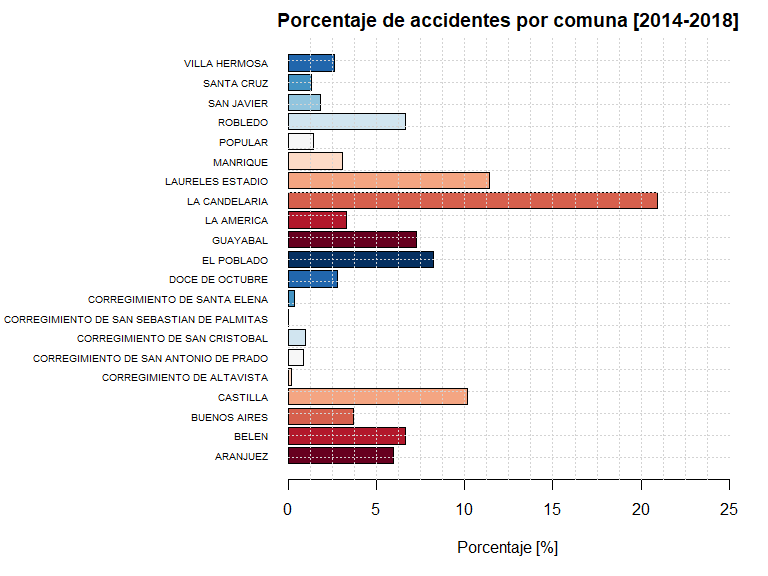

La menor ocurrencia de accidentes se presenta en los corregimientos. Este resultado era de esperarse, ya que los corregimientos correspondes a zonas rurales de la ciudad, las cuales no alcanza a llegar al 1% de la accidentalidad total reistrada durante el periodo de estudio, por tanto, se toma la decisión de eliminar los datos de los corregimientos para no afectar los análisis y los modelos predictivos.

Se vuelve a graficar la distribución de la acciedentalidad por comunas para verificar el cambio realizado y los nuevos porcentajes de accidentalidad.

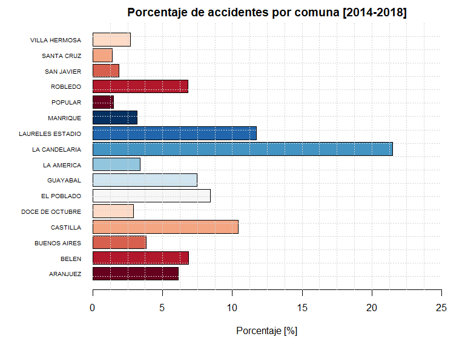

La comuna con mayor porcentaje de accidentes entre los años 2014 y 2018 es *La Candelaria*, que se compone de los barrios de la zona central de la ciudad y con mayor flujo vehicular, debido a la alta concentración de comercios y entidades administrativas de la ciudad. A esta comuna le sigue la de *Laureles - Estadio*, en la cual confluyen diferentes vías principales de la ciudad como son la avenida San Juan y las carreras 70 y 80. A estás comunas les sigue la de *Castilla*, que ocupa cierto tramo de la autopista norte.

#### **Accidentalidad por barrios**

Se realiza a continuación un pareto donde se muestran los 10 primeros barrios de acuerdo al número de accidentes ocurridos durante el periodo comprendido entre 2014 y 2018.

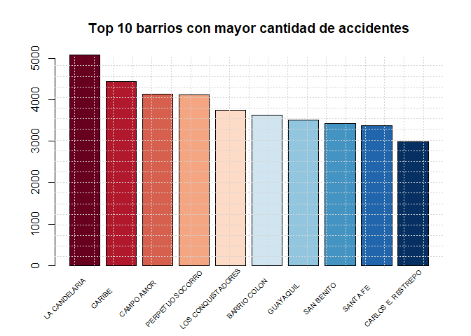

```r
## conteo
acc_barrio <- table(df$BARRIO)
acc_barrio <- sort(acc_barrio, decreasing=TRUE)
acc_barrio <- head(acc_barrio,10)

## plot
barrios_plot <- barplot(acc_barrio,
        main="Top 10 barrios con mayor cantidad de accidentes",
        xlab = "",
        col=brewer.pal(n = 10, name = "RdBu"),
        xaxt="n")
labs <- names(acc_barrio)
text(cex=0.65, x=barrios_plot-.7, y=-800, labs, xpd=TRUE, srt=45)
grid(20,20, lty = 3, lwd = 0.1)
```

Se observa que entre los 265 barrios de la ciudad de Medellín, fueron *La Candelaria* y *Caribe* los que presentaron la mayor cantidad de accidentes durante el periodo de estudio. El primer barrio se encuentra en la zona central de la ciudad, con mayor accidentalidad debido a lo explicado antes. El segundo cuenta con una alta afluencia de vehículos ya que por el cruza la carrera 46 C, muy utilizada por los vehículos que se dirigen hacia el norte de la ciudad.

El siguiente gráfico muestra la distribución de la accidentalidad por mes cada año.

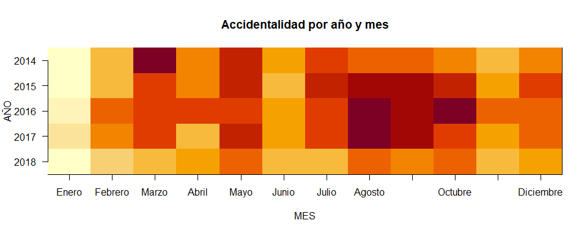

En general, la menor ocurrencia de accidentes se encuentra en el mes de enero, que es un mes donde no se celebra alguna festividad importante en la ciudad y el flujo de personas es relativamente bajo, debido a los foráneos que regresan a sus lugares de procedencia en el mes de diciembre.

En contraste, en promedio, agosto es el mes con la mayor ocurrencia de accidentes. Se debe tener en cuenta que en este mes se celebra la *Feria de las Flores* y que la afluencia de personas es alta y la ciudad cuenta con la llegada de personas de todas partes en estas fechas.

En los meses de marzo, mayo, septiembre y octubre también se observan valores altos de accidentalidad en la ciudad, mentras que el resto de los meses la accidentalidad parece mantenerse en un promedio.

### Gráfico clase y tipo de accidente

En las bases de datos la ocurrencia de accidentes se encuentra clasificada de acuerdo a la gravedad y clase de acccidentes. En la siguiente gráfica se muestra cómo están distribuídos los accidentes respecto a estos parámetros.

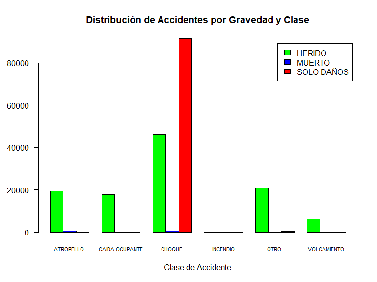

La mayor cantidad de accidentes presentados son *CHOQUES*, de los cuales en su mayoría solo ocurren daños, seguido de eventos con heridos y eventos con muertes. La clase *OTROS* presenta una alta participación en la ocurrencia de accidentes. Habría que realizar un estudio más profundo para identificar qué tipo de eventos se presentan en estos casos.

Los *ATROPELLOS* y *CAIDA DE OCUPANTES* presentan una alta cantidad de personas heridas, en ninguno de estos casos se observa solo ocurrencia de daños y ocurren muchas más muertes por los atropellos que por las caídas.

Los *VOLCAMIENTOS* se presentan en su mayoría heridos, seguido de solo daños y solo 4 muertes ocurridas en el período de estudio. Finalmente, la clase con menos participación es la de *INCENDIO*, con 15 eventos con daños y 14 con heridos sin ninguna ocurrencia de muertes. Se procede a eliminar esta clase del estudio debido a su baja participación.

```r
## se elimina incendio.
df <- subset(df, CLASE != "INCENDIO")
table(df$CLASE)
```

```
     ATROPELLO CAIDA OCUPANTE         CHOQUE           OTRO    VOLCAMIENTO
         19919          17791         138229          21243           6351
```

## **Modelamiento**

Para la selección del modelo predictivo que se utilizará para construir la aplicación en Shiny a partir de los datos de accidentalidad en Medellín, se procede a comparar diferentes modelos y evaluar su desempeño en entrenamiento y prueba calculando la *el error cuadrático medio* (*MSE*). En este caso, variaciones de más del 15% entre los *MSE* obtenidos en ambos conjuntos, se considerarán sospechosas de sobreentrenamiento del modelo.

Previamente se realizó la limpieza de las bases de datos obtenidad de **MEData**. Estas se almacenaron en el archivo en el dataframe *df*, y a partir de este punto, realizaremos una copia de ese dataframe que llamaremos *accidentalidad*.

```r
# - Realizamos copia del dataframe
accidentalidad <- df
head(accidentalidad)
```

[output not shown]

Primero se seleccionan las variables que se utilizarán, que para este trabajo serán: *DIA*, *MES*, *SEMANA*, *FECHAS_ESP*, *PERIODO*, *COMUNA*, *BARRIO* y *CLASE*. Además de que se agrega la variable *DIA_ANNO* que muestra el número del día del año (1-365).

Luego se procede a dar un formato adecuado a las variables; se convertirá las variables *BARRIO*, *COMUNAS* y *CLASE* a categóricas (factor). Se tiene un número finito de barrios, sin embargo es bastante alto (271), por lo que se manejará la variable como continua y no como categórica. Las otras variables se convertirán nuevamente a factor luego de convertirlas en numéricas, ya que los modelos pueden trabajar mejor si se ingresan números en lugar de texo. Adicionalmente, las variables *MES* y *FECHAS_ESP* se trabajarán como categórica, mientras que se tratarán las variables *DIA*, *SEMANA* y *PERIODO* como continuas.

```r
library(lubridate)

## se seleccionan variables
accidentalidad <- select(accidentalidad, FECHA, DIA, MES, SEMANA, FECHAS_ESP, PERIODO, COMUNA, BARRIO, CLASE)
accidentalidad$DIA_ANNO <- yday(accidentalidad$FECHA)

## variables a factores
accidentalidad$MES <- as.factor(accidentalidad$MES)
accidentalidad$FECHAS_ESP <- as.factor(accidentalidad$FECHAS_ESP)
accidentalidad$CLASE <- as.factor(accidentalidad$CLASE)
accidentalidad$BARRIO <- as.factor(accidentalidad$BARRIO)
accidentalidad$COMUNA <- factor(accidentalidad$COMUNA,
                                levels = c("POPULAR","SANTA CRUZ", "MANRIQUE","ARANJUEZ","CASTILLA",
             "DOCE DE OCTUBRE", "ROBLEDO", "VILLA HERMOSA", "BUENOS AIRES",
             "LA CANDELARIA", "LAURELES ESTADIO", "LA AMERICA", "SAN JAVIER",
             "EL POBLADO", "GUAYABAL", "BELEN"))

## factores a numérico y luego a factores
accidentalidad$FECHAS_ESP <- as.factor(as.numeric(accidentalidad$FECHAS_ESP))
accidentalidad$CLASE <- as.factor(as.numeric(accidentalidad$CLASE))
accidentalidad$COMUNA <- as.factor(as.numeric(accidentalidad$COMUNA))
accidentalidad$BARRIO <- as.numeric(accidentalidad$BARRIO)

## DIA y SEMANA a numéricas
accidentalidad$DIA <- as.numeric(accidentalidad$DIA)
accidentalidad$SEMANA <- as.numeric(accidentalidad$SEMANA)

## primeros registros
head(accidentalidad)
```

Se pretende precedir la accidentalidad por mes, semana y día, por lo que se crean tres nuevos dataframes. El primero, realizando un conteo de la accidentalidad por día, en el segundo se cuenta la accidentalidad por semana, y el tercero cuenta la accidentalidad por mes para cada año. Para esto se utilizan las funciones `group_by` y `summarise` del paquete **dplyr**.

Para cada dataframe se procede a entrenar 3 modelos y calcular su desempeño tanto en los datos de entrenamiento como en los datos de validación. Debido a que la cantidad de accidentes es un conteo, se hará uso del *modelo lineal generalizado con distribución Poisson*. El segundo modelo a entrenar será el de *k-Vecinos cercanos*, para el cual se planea realizar un proceso previo para seleccionar un k óptimo para cada conjunto de datos. Por último, se ajustará un modelo de *Bosque Aleatorio*, para un determinado número de árboles.

Se procederá a calcular el **MSE** de entrenamiento y prueba para cada modelo y calcular la diferencia porcentual entre los mismos, de manera que se pueda establecer si el modelo está sobreentrenado (diferencia mayor al **15%**) o no.

#### **Modelamiento de accidentalidad por día**

Se realiza el conteo del número de accidentes ocurridos cada día durante el período comprendido entre el 2014 y el 2018.

```r
### conteo
detach(package:dplyr)
require(dplyr)
acc_dia  <- accidentalidad %>%
    group_by(PERIODO, DIA_ANNO, FECHAS_ESP, COMUNA, BARRIO, CLASE) %>%
    summarise(CANTIDAD = n())


head(acc_dia)
```

Se observa la distribución de la ocurrencia de accidentes.

```r
## conteo accidentes
table(acc_dia$CANTIDAD)
```

Se dividen los datos en entrenamiento y prueba.

```r
### filtramos los datos
trainSet_dia <- subset(acc_dia,
                      subset = (PERIODO %in%
                                    c(2014,2015,2016,2017)))
testSet_dia <- subset(acc_dia,
                  subset = (PERIODO %in% 2018))

## dimensiones
dim(trainSet_dia)
dim(testSet_dia)
```

Ahora se procede realizar el entrenamiento y predicción de accidentalidad utilizando los modelos mencionados anteriormente.

**Modelo lineal generalizado - Distribución Poisson**

Se procede a ajustar el modelo con todas las variables utilizando la función `glm`, especificando la distribución Poisson como argumento.

```r
modeloPois_dia <- glm(CANTIDAD~., data=trainSet_dia, family = "poisson")
summary(modeloPois_dia)
```

El *PERIODO* no resulta ser significativo para el modelo, con un *valor p* bastante alto que no brinda evidencia para rechazar la hipótesis nula, por lo que se concluye que en este modelo ingresar el año no aporta información.

La inclusión de las comunas 5, 10, 11, 14, 15 y 16 es bastante significativa para el modelo. Cabe destacar que las comunas mencionadas son las de mayor ocurrencia de accidentalidad en Medellín durante el periodo de estudio. Entre las clases de accidentes, los CHOQUES (CLASE3) son los de mayor ocurrencia, además de los más significativos para el modelo ajustado, con un *valor p* que es esencialmente cero, seguido de la clase de accidentes VOLCAMIENTO (CLASE6).

Por último, los días No Laborales no parecen ser significativos para el ajuste, de acuerdo con este modelo. En contraste la inclusión de los días laborales es muy significativa. Además de que la variable clave para la predicción con este modelo (columna *DIA_ANNO*) muestra un *valor p* bastante alto, que indica que no puede favorecer la hipótesis alternativa y por tanto dicha variable no presenta relación alguna con la variable de respuesta bajo este escenario. Esto representa un inconveniente, ya que el objetivo es predecir la accidentalidad en Medellín por día.

Se procede a continuación a eliminar variables del modelo de una en una para observar el efecto separado sobre el ajuste del modelo y las otras variables.

```r
## modelo 2
## eliminando variable PERIODO
modeloPois_dia2 <- glm(CANTIDAD~.-PERIODO, data=trainSet_dia, family = "poisson")
summary(modeloPois_dia2)
```

La eliminación de la columna *PERIODO* no altera demasiado la interacción de las demás variables con la variable de respuesta, salvo el *INTERCEPTO*, que ahora se hace muy significativo para el modelo, con un *valor p* bastante bajo. La interacción de la columna DIA_ANNO con la variable respuesta no se vio afectada.

Se procede ahora a eliminar la variable CLASE, para observar si la interacción deseada mejora.

```r
## modelo 3
## eliminando variables PERIODO y CLASE
modeloPois_dia3 <- glm(CANTIDAD~.-CLASE, data=trainSet_dia, family = "poisson")
summary(modeloPois_dia3)
```

Se observa en este caso que el eliminar la variable CLASE tiene un efecto positivo en la interacción de las demás variables con la vaiable de respuesta. En este caso, aumenta el número de comunas que el modelo considera significativas para el ajuste. Además de que el *valor p* para la columna BARRIO disminuyó considerablemente.

La inclusión de la columna *PERIODO* provoca que el INTERCEPTO deje de ser significativo para el modelo. Además, la columna DIA_ANNO sigue mostrando un *valor p* que no permite rechazar la hipótesis nula.

Se ajusta ahora un cuarto modelo eliminando las columnas CLASE y PERIODO.

```r
## modelo 4
## eliminando variables PERIODO y CLASE
modeloPois_dia4 <- glm(CANTIDAD~.-PERIODO-CLASE, data=trainSet_dia, family = "poisson")
summary(modeloPois_dia4)
```

En este caso tanto el *INTERCEPTO* como *DIA_ANNO* pasan a ser ligeramente significativas para el modelo, con un *valor p* menor al 5% que no es muy contundente para rechazar la hippótesis nula, pero es mejor que los resultados arrojados por los ajustes anteriores, tomando en cuenta el objetivo del ajuste, que es poder predecir la accidentalidad por día en Medellín con cierto grado de seguridad.

A continuación se calcula el MSE para los datos de entrenamiento y validación con cada uno de los cuatro ajustes anteriores. Además se calcula el porcentaje de variación para descartar sobreentrenamiento.

```r
### MSE
library(Metrics)

## modelo Poisson 1
## train
predPois_tr_d1 <- predict(modeloPois_dia, newdata = trainSet_dia)
mseTr_Pois_d1 <- mse(trainSet_dia$CANTIDAD, predPois_tr_d1)

## test
predPois_ts_d1 <- predict(modeloPois_dia, newdata = testSet_dia)
mseTs_Pois_d1 <- mse(testSet_dia$CANTIDAD, predPois_ts_d1)


## modelo Poisson 2
## train
predPois_tr_d2 <- predict(modeloPois_dia2, newdata = trainSet_dia)
mseTr_Pois_d2 <- mse(trainSet_dia$CANTIDAD, predPois_tr_d2)

## test
predPois_ts_d2 <- predict(modeloPois_dia2, newdata = testSet_dia)
mseTs_Pois_d2 <- mse(testSet_dia$CANTIDAD, predPois_ts_d2)


## modelo Poisson 3
## train
predPois_tr_d3 <- predict(modeloPois_dia3, newdata = trainSet_dia)
mseTr_Pois_d3 <- mse(trainSet_dia$CANTIDAD, predPois_tr_d3)

## test
predPois_ts_d3 <- predict(modeloPois_dia3, newdata = testSet_dia)
mseTs_Pois_d3 <- mse(testSet_dia$CANTIDAD, predPois_ts_d3)


## modelo Poisson 4
## train
predPois_tr_d4 <- predict(modeloPois_dia4, newdata = trainSet_dia)
mseTr_Pois_d4 <- mse(trainSet_dia$CANTIDAD, predPois_tr_d4)

## test
predPois_ts_d4 <- predict(modeloPois_dia4, newdata = testSet_dia)
mseTs_Pois_d4 <- mse(testSet_dia$CANTIDAD, predPois_ts_d4)

## variacion
variacion_Pois_d1 <- (abs(mseTs_Pois_d1-mseTr_Pois_d1)/mseTr_Pois_d1)*100
variacion_Pois_d2 <- (abs(mseTs_Pois_d2-mseTr_Pois_d2)/mseTr_Pois_d2)*100
variacion_Pois_d3 <- (abs(mseTs_Pois_d3-mseTr_Pois_d3)/mseTr_Pois_d3)*100
variacion_Pois_d4 <- (abs(mseTs_Pois_d4-mseTr_Pois_d4)/mseTr_Pois_d4)*100


### tabla comparación
comp_poisson_d <- data.frame(Ajuste_Pois=c("Ajuste1", "Ajuste2","Ajuste3", "Ajuste4"),
                           MSE_train = c(mseTr_Pois_d1, mseTr_Pois_d2, mseTr_Pois_d3, mseTr_Pois_d4),
                           MSE_test = c(mseTs_Pois_d1, mseTs_Pois_d2, mseTs_Pois_d3, mseTs_Pois_d4),
                           variacion_percent = c(variacion_Pois_d1, variacion_Pois_d2,
                                         variacion_Pois_d3, variacion_Pois_d4))
comp_poisson_d
```

Los resultados obtenidos para los cuatro ajustes son buenos, teniendo en cuenta que la variación máxima del MSE caculado para ambos conjuntos debe ser de 15%. El **cuarto ajuste** presenta una variación de **1.11%** y es la más alta. Este ajuste, aunque sacrifica la variable CLASE, permite ganar significancia a la variable DIA_ANNO, y por tanto se toma para realizar la comparación con los modelos que se estudiarán más adelante.

**K Vecinos Cercanos**

El segundo modelo a ajustar es el *K-Vecinos Cercanos* para Regresión. Este hace parte de la librería *caret*.

Antes de realizar el ajuste del modelo, se selecciona un valor de $K$ óptimo de acuerdo al valor mínimo obtenido para el *RMSE*. Para hacerlo se tomará una muestra del 5% de los datos de entrenamiento ya que debido a la alta dimensionalidad de los datos conllevaría un alto costo computacional el poder realizar el proceso con los datos completos.

```r
library(caret)
set.seed(12345)

## 5% datos
n <- dim(trainSet_dia)[1]
trFrac <- sample(1:n, round(0.05*n), replace=FALSE)
trSet_05 <- trainSet_dia[trFrac,]


## k óptimo
trControl<-trainControl(method = "LGOCV",p=0.75,number = 15)
modeloK_dia<-train(CANTIDAD~.,
             data       = trSet_05,
             method     = "knn",
             tuneGrid   = expand.grid(k = 1:50),
             trControl  = trControl,
             metric     = "rmse")

print(modeloK_dia)
```

```r
## plot
plot(modeloK_dia)
```

De acuerdo con el modelo, el valor óptimo de $k$ es $k=50$, sin embargo, se observa que el mse no varía mucho a partir de $k=15$, por lo que se toma este valor para el entrenamiento posterior.

```r
library(caret)

## X train
## la variable cantidad está en la posición 7
trainX_d <- trainSet_dia[,-7]

## Y train
trainY_d <- trainSet_dia$CANTIDAD

## KNN
modeloKNN_dia <- knnreg(trainX_d,trainY_d,k=15, na.rm=TRUE)
modeloKNN_dia
```

Se realiza la predicción para los datos de entrenamiento y se calcula el mse.

```r
## Predicción entrenamiento.
predknn_tr_d <- predict(modeloKNN_dia, trainX_d)

##métricas
library(Metrics)
(mseTr_knn_d <- mse(trainY_d, predknn_tr_d))
```

Para prueba.

```r
## testX y testY
testX_d <- testSet_dia[,-7]
testY_d <- testSet_dia$CANTIDAD


## Predicción prueba
predknn_ts_d <- predict(modeloKNN_dia, testX_d)

##métricas
library(Metrics)
(mseTs_knn_d <- mse(testY_d, predknn_ts_d))
```

Se calcula la diferencia porcentual.

```r
### Porcentaje
variacion_knn_d <- (abs(mseTs_knn_d-mseTr_knn_d)/mseTr_knn_d)*100

paste0("La variación entre los mse de entrenamiento y prueba para el modelo de Vecinos cercanos es de ", round(variacion_knn_d,2), "%")
```

Los valores de MSE obtenidos en este con el modelo de *Vecinos Cercanos* son más bajos que para el modelo anterior. En este caso se calcula una diferencia en el MSE de 14.9%, que se encuentra en el límite. Se puede decir entonces que el modelo no está sobreentrenado, aunque la diferencia entre ambos valores de MSE es alta.

**Bosque Aleatorio**

```r
library(randomForest)

## muestra del 5%
set.seed(12345)
n <- dim(trainSet_dia)[1]
trFrac_d <- sample(1:n, round(0.05*n), replace=FALSE)
trSet_05_d <- trainSet_dia[trFrac_d,]


modelo_ntree_d <- randomForest(CANTIDAD ~ ., data = trSet_05_d,
                                    ntree = 500,importance = TRUE)

oob_mse_d <- data.frame(rf_mse = modelo_ntree_d$mse,
                      arboles = seq_along(modelo_ntree_d$mse))
ggplot(data = oob_mse_d, aes(x = arboles, y = rf_mse )) +
  geom_line() +
  labs(title = "Evolución del out-of-bag-error vs número árboles",
       x = "nº árboles") +
  theme_bw()
```

A partir de 100 árboles el error no varía mucho. Se selecciona este valor para entrenar el modelo con los datos de entrenamiento.

```r
## entrenamiento Random Forest
set.seed(12345)

modeloRF_dia <- randomForest(CANTIDAD~., data=trainSet_dia, ntree=100)
modeloRF_dia
```

```r
## Predicción entrenamiento.
predRF_tr_d <- predict(modeloRF_dia, newdata = trainSet_dia)

##métricas
library(Metrics)
(mseTr_rf_d <- mse(trainSet_dia$CANTIDAD, predRF_tr_d))
```

```r
## Predicción prueba
predRF_ts_d <- predict(modeloRF_dia, newdata = testSet_dia)

## mse
(mseTs_rf_d <- mse(testSet_dia$CANTIDAD, predRF_ts_d))
```

```r
### Porcentaje
variacion_rf_d <- (abs(mseTs_rf_d-mseTr_rf_d)/mseTr_rf_d)*100

paste0("La variación entre los mse de entrenamiento y prueba para el modelo de Bosque Aleatorio entrenado con 20 árboles es de ", round(variacion_rf_d,2), "%")
```

La variación del MSE es de 13.42% menor que la variación obtenida para el ajuste anterior y que el límite establecido, por lo que el modelo no se encuentra sobreentrenado. El ajuste del modelo con 100 árboles conlleva un costo computacional bastante alto, puesto que el ajustar el modelo demora al menos 30 minutos.

Se muestra a continuación la importancia de las variables en aras de saber qué tan influyente es la variable DIA_ANNO para la predicción de la accidentalidad.

```r
## importancia
varImpPlot(modeloRF_dia)
```

Se observa que la variable *COMUNA* es la de mayor influencia, seguida de *BARRIO*, *CLASE* y *DIA_ANNO*. Las variables *FECHAS_ESP* y *PERIODO* no son tan inlfuyentes para el modelo. Se realiza un segundo ajuste sin contar estas variables.

```r
## entrenamiento Random Forest con FECHAS_ESP y PERIODO.
set.seed(12345)

library(randomForest)
modeloRF_dia_2 <- randomForest(CANTIDAD~.-FECHAS_ESP-PERIODO, data=trainSet_dia, ntree=100)
modeloRF_dia_2
```

Se observa una disminución considerable en el porcentaje de varianza explicada por el modelo, que para el primer ajuste también era baja. Esto indica que pueden hacer falta variables dentro del ajuste que permitan alcanzar un mayor valor de varianza explicada y permitan mejores predicciones de la accidentalidad. A continuación se calcula el MSE para los conjuntos de entrenamiento y validación.

```r
## Predicción entrenamiento.
predRF_tr_d2 <- predict(modeloRF_dia_2, newdata = trainSet_dia)

##métricas
(mseTr_rf_d2 <- mse(trainSet_dia$CANTIDAD, predRF_tr_d2))
```

```r
## Predicción prueba
predRF_ts_d2 <- predict(modeloRF_dia_2, newdata = testSet_dia)

## mse
(mseTs_rf_d2 <- mse(testSet_dia$CANTIDAD, predRF_ts_d2))
```

```r
### Porcentaje
variacion_rf_d2 <- (abs(mseTs_rf_d2-mseTr_rf_d2)/mseTr_rf_d2)*100

paste0("La variación entre los mse de entrenamiento y prueba para el modelo de Bosque Aleatorio entrenado con 20 árboles es de ", round(variacion_rf_d2,2), "%")
```

Aunque los valores de MSE en este segundo ajuste son más alto, la diferencia entre el MSE calculado para ambos conjuntos fue más baja que la obtenida con el modelo ajustado con todas las variables. Se toma este segundo ajuste para realizar la comparación entre los tres modelos.

A continuación se presenta un resumen de los resultados obtenidos para los tres modelos.

```r
## RESULTADOS MODELOS AJUSTADOS
resultados_dia <- data.frame(Modelo=c("GLM(Poisson)", "KNN", "Random Forest"),
                             mse_train = c(mseTr_Pois_d4, mseTr_knn_d, mseTr_rf_d2),
                             mse_test = c(mseTs_Pois_d4, mseTs_knn_d, mseTs_rf_d2),
                             Diff_mse = c(paste0(round(variacion_Pois_d4,2),"%"),
                                           paste0(round(variacion_knn_d,2),"%"),
                                           paste0(round(variacion_rf_d2,2),"%")))

resultados_dia
```

Se observa que los valores más altos de MSE se obtuvieron para el *GLM (Poisson)*, seguido de *KNN* y *Random Forest*. Sin embargo, la diferencia entre dicho valor para ambos conjuntos aumenta, siendo *GLM (Poisson)* el que arrojó la menor diferencia y *KNN* el de mayor.

El error cuadrático para los datos de validación es bastante alto con el modelo *GLM (Poisson)*, tomando en cuenta que la cantidad máxima de accidentes de acuerdo a los filtros introducidos sería de 9, y que se tienen muchos datos únicos. Por otro lado, el modelo *KNN* muestra una diferencia de *MSE* bastante cercana al límite, por lo que es propenso a estar sobreestimado, además de que el tiempo necesario para el ajuste del modelo es un poco alto. En este caso, el mejor modelo para la predicción de la accidentalidad por días sería el modelo de **Bosque Aleatorio**, el cual no solo muestra una diferencia en el MSE bastante baja, si no que los valores calculados de MSE son bajos individualmente.

#### **Modelamiento de accidentalidad por semana**

Se realiza un proceso similar al hecho para los datos de accidentalidad por día, solo que ahora se excluye la variable DIA del conteo. Ya que la variable FECHAS_ESP hace referencia a un díua puntual, no tiene sentido incluirlo en esta parte del análisis.

```r
### conteo
detach(package:dplyr)
require(dplyr)
acc_semana  <- accidentalidad %>%
    group_by(PERIODO, MES, SEMANA, COMUNA, BARRIO, CLASE) %>%
    summarise(CANTIDAD = n())


head(acc_semana)
```

Se observa la distribución de la cantidad de accidentes por semanas.

```r
barplot(table(acc_semana$CANTIDAD),
        xlab="Cantidad de Accidentes",
        ylab="Distribución de accidentes",
        main = "Distribución de la cantidad de accidentes por semana")
```

Nuevamente, se observa un alto número de accidentes únicos, esto debido a que el conteo se encuentra discretizado por diferentes variables. Si se observa la relación entre la accidentalidad con la variable semana.

```r
plot(acc_semana$SEMANA,acc_semana$CANTIDAD,
     xlab="Semana",
     ylab="Cantidad de accidentes",
     main="Accidentalidad por semana")
```

No se observa un patrón definido al graficar la accidentalidad por semana. Se procede ahora a dividir los datos en entrenamiento (2014 a 2017) y prueba (datos del 2018).

```r
### filtramos los datos
trainSet_sem <- subset(acc_semana,
                      subset = (PERIODO %in%
                                    c(2014,2015,2016,2017)))
testSet_sem <- subset(acc_semana,
                  subset = (PERIODO %in% 2018))

## dimensiones
dim(trainSet_sem)
dim(testSet_sem)
```

Se ajustan los mismos tres modelos que se entrenaron en la sección anterior, esta vez para predecir la accidentalidad en Medellín por semana.

**Modelo lineal generalizado - Distribución Poisson**

Se ajusta el modelo con todas las variables para los datos de entrenamiento.

```r
## modelo con todas las variables
modeloPois_sem <- glm(CANTIDAD~., data=trainSet_sem, family = "poisson")
summary(modeloPois_sem)
```

En este caso, la variable *SEMANA* no es significativa para el ajuste del modelo. Se observa, además, que en promedio solo la adición de los meses de febrero y marzo aporta información para el ajuste. En este caso, la mayoría de las comunas son significativas para el ajuste, como muestran sus *valores p*, además de que para la variable *BARRIO* dicho valor es bastante bajo, permitiendo rechazar la hipótesis nula.

```r
## se elimina MES
modeloPois_sem2 <- glm(CANTIDAD~.-MES, data=trainSet_sem, family = "poisson")
summary(modeloPois_sem2)
```

Se observa una disminución considerable en el *valor p* calculado para la variable SEMANA en comparación con el ajuste anterior. Este valor es lo suficientemente contundente para rechazar la hipótesis nula de entrada. Además, el ajuste muestra que las otras variables son bastante significativas para el modelo, por lo que no se realizan más modificaciones.

A continuación se calcula el MSE para los datos de entrenamiento y validación con cada uno de los dos ajustes anteriores. Además se calcula el porcentaje de variación para descartar sobreentrenamiento.

```r
library(Metrics)
## ajuste Poisson 1
### train
predPois_tr_s <- predict(modeloPois_sem, newdata = trainSet_sem)
mseTr_Pois_s <- mse(trainSet_sem$CANTIDAD, predPois_tr_s)

## test
predPois_ts_s <- predict(modeloPois_sem, newdata = testSet_sem)
mseTs_Pois_s <- mse(testSet_sem$CANTIDAD, predPois_ts_s)

## ajuste Poisson 2
### train
predPois_tr_s2 <- predict(modeloPois_sem2, newdata = trainSet_sem)
mseTr_Pois_s2 <- mse(trainSet_sem$CANTIDAD, predPois_tr_s2)

## test
predPois_ts_s2 <- predict(modeloPois_sem2, newdata = testSet_sem)
mseTs_Pois_s2 <- mse(testSet_sem$CANTIDAD, predPois_ts_s2)


## variaciones
variacion_Pois_s1 <- (abs(mseTs_Pois_s-mseTr_Pois_s)/mseTr_Pois_s)*100
variacion_Pois_s2 <- (abs(mseTs_Pois_s2-mseTr_Pois_s2)/mseTr_Pois_s2)*100


### comparación
### tabla comparación
comp_poisson_s <- data.frame(Ajuste_Pois=c("Ajuste1", "Ajuste2"),
                           MSE_train = c(mseTr_Pois_s, mseTr_Pois_s2),
                           MSE_test = c(mseTs_Pois_s, mseTs_Pois_s2),
                           variacion_percent = c(variacion_Pois_s1, variacion_Pois_s2))
comp_poisson_s
```

Se observa que el modelo se desempeña ligeramente mejor en con los datos de entrenamiento para ambos ajustes. La diferencia porcentual entre los valores calculados de MSE es menor para el segundo ajuste del modelo.

Debido a que en el segundo ajuste la variable *SEMANA* muestra cierto grado de significancia, se toma este como el modelo a comparar con el ajuste de *K vecinos cercanos* y *Random Forest* para la predicción de la accidentalidad por semana en Medellín.

**K Vecinos Cercanos**

Se selecciona un valor de $K$ óptimo de acuerdo al valor mínimo obtenido para el *MSE*. Para hacerlo se tomará una muestra del 5% de los datos de entrenamiento ya que debido a la alta dimensionalidad de los datos conllevaría un alto costo computacional el poder realizar el proceso con los datos completos.

```r
library(caret)
set.seed(12345)

## 5% datos
n <- dim(trainSet_sem)[1]
trFrac_s <- sample(1:n, round(0.05*n), replace=FALSE)
trSet_05_s <- trainSet_sem[trFrac_s,]


## k óptimo
trControl<-trainControl(method = "LGOCV",p=0.75,number = 15)
modeloK_sem<-train(CANTIDAD~.,
             data       = trSet_05_s,
             method     = "knn",
             tuneGrid   = expand.grid(k = 1:100),
             trControl  = trControl,
             metric     = "mse")

print(modeloK_sem)
```

```r
plot(modeloK_sem)
```

Según el modelo, el valor óptimo de vecinos para este escenario es de 78, sin embargo, la disminución del error no es muy pronunciada a partir de los 10 vecinos, por lo que se toma $k=20$ para realizar el ajuste del modelo.

```r
library(caret)

## X train
## la variable cantidad está en la posición 8
trainX_s <- trainSet_sem[,-7]

## Y train
trainY_s <- trainSet_sem$CANTIDAD

## KNN
modeloKNN_sem <- knnreg(trainX_s,trainY_s,k=20, na.rm=TRUE)
modeloKNN_sem
```

```r
## Predicción entrenamiento.
predknn_tr_s <- predict(modeloKNN_sem, trainX_s)

##métricas
library(Metrics)
(mseTr_knn_s <- mse(trainY_s, predknn_tr_s))
```

```r
## testX y test
testX_s <- testSet_sem[,-7]
testY_s <- testSet_sem$CANTIDAD


## Predicción prueba
predknn_ts_s <- predict(modeloKNN_sem, testX_s)

##métricas
library(Metrics)
(mseTs_knn_s <- mse(testY_s, predknn_ts_s))
```

```r
### Porcentaje
variacion_knn_s <- (abs(mseTs_knn_s-mseTr_knn_s)/mseTr_knn_s)*100

paste0("La variación entre los mse de entrenamiento y prueba para el modelo de Vecinos cercanos es de ", round(variacion_knn_s,2), "%")
```

Se tienen una diferencia del 23.3% entre el MSE para los datos de entrenamiento y validación. Dicha diferencia está por encima del 15% establecido como límite, por lo que en este caso hay evidencia de sobreentrenamiento del modelo. Se entrena nuevamente el modelo con $k=40$ vecinos para observar si el desempeño mejora.

```r
## KNN 78 vecinos
modeloKNN_sem_2 <- knnreg(trainX_s,trainY_s,k=40, na.rm=TRUE)
modeloKNN_sem_2
```

Ahora se calcula el MSE para ambos conjuntos.

```r
## Predicción entrenamiento.
predknn_tr_s2 <- predict(modeloKNN_sem_2, trainX_s)

##métricas
library(Metrics)
(mseTr_knn_s2 <- mse(trainY_s, predknn_tr_s2))
```

```r
## Predicción prueba
predknn_ts_s2 <- predict(modeloKNN_sem_2, testX_s)

##métricas
(mseTs_knn_s2 <- mse(testY_s, predknn_ts_s2))
```

```r
### Porcentaje
variacion_knn_s2 <- (abs(mseTs_knn_s2-mseTr_knn_s2)/mseTr_knn_s2)*100

paste0("La variación entre los mse de entrenamiento y prueba para el modelo de Vecinos cercanos es de ", round(variacion_knn_s2,2), "%")
```

Se toma este ajuste para las comparaciones con los otros dos modelos.

**Bosque Aleatorio**

Se realiza el proceso para seleccionar un número óptimo de árboles para predecir la accidentalidad por semana tomando una muestra del 10% de los datos de entrenamiento.

```r
library(randomForest)

## muestra del 10%
set.seed(12345)
n <- dim(trainSet_sem)[1]
trFrac_s <- sample(1:n, round(0.1*n), replace=FALSE)
trSet_10_s <- trainSet_sem[trFrac_s,]


modelo_ntree_s <- randomForest(CANTIDAD ~ ., data = trSet_10_s,
                                    ntree = 500,importance = TRUE)

oob_mse_s <- data.frame(rf_mse = modelo_ntree_s$mse,
                      arboles = seq_along(modelo_ntree_s$mse))
ggplot(data = oob_mse_s, aes(x = arboles, y = rf_mse )) +
  geom_line() +
  labs(title = "Evolución del out-of-bag-error vs número árboles",
       x = "nº árboles") +
  theme_bw()
```

Alrededor de los 100 árboles no se observa una disminución significativa del error. Se toma este valor y se ajusta el modelo perdictivo.

```r
## entrenamiento Random Forest
set.seed(12345)

modeloRF_sem <- randomForest(CANTIDAD~., data=trainSet_sem, ntree=100)
modeloRF_sem
```

El modelo ajustado con 100 árboles explica un 59.59% de la varianza, puede que hagan falta variables para poder aumentar el porcentaje de varianza explicada por el modelo. Se realiza ahora la predicción para los conjuntos de entrenamiento y prueba y se calcula el MSE.

```r
## Predicción entrenamiento.
predRF_tr_s <- predict(modeloRF_sem, newdata = trainSet_sem)

##métricas
library(Metrics)
(mseTr_rf_s <- mse(trainSet_sem$CANTIDAD, predRF_tr_s))
```

```r
## Predicción prueba
predRF_ts_s <- predict(modeloRF_sem, newdata = testSet_sem)

## mse
(mseTs_rf_s <- mse(testSet_sem$CANTIDAD, predRF_ts_s))
```

```r
### Porcentaje
variacion_rf_s <- (abs(mseTs_rf_s-mseTr_rf_s)/mseTr_rf_s)*100

paste0("La variación entre los mse de entrenamiento y prueba para el modelo de Bosque Aleatorio entrenado con 150 árboles es de ", round(variacion_rf_s,2), "%")
```

La diferencia entre el MSE para ambos conjuntos está por encima del límite (15%), indicando que el modelo ajustado con todas las variables está sobreentrenado. El modelo se desempeña mejor para el conjunto de entrenamiento. Además, los valores de MSE son más bajos que los obtenidos para el método de Vecinos Cercanos.

Se observa la importancia de las variables en el ajuste.

```r
## importancia
varImpPlot(modeloRF_sem)
```

En este caso las variables *MES* y *PERIODO* son las de menor importancia. Se procede a realizar un segundo ajuste sin contar estas variables para observar el desempeño del modelo de Bosque Aleatorio.

```r
## entrenamiento Random Forest sin PERIODO y MES
set.seed(12345)

modeloRF_sem_2 <- randomForest(CANTIDAD~.-PERIODO-MES, data=trainSet_sem, ntree=100)
modeloRF_sem_2
```

Este ajuste explica un 41.21% de la varianza, menos que el ajuste anterior. Se procede a calcular su desempeño con los conjuntos de entrenamiento y prueba calculando el MSE.

```r
## Predicción entrenamiento.
predRF_tr_s2 <- predict(modeloRF_sem_2, newdata = trainSet_sem)

##métricas
(mseTr_rf_s2 <- mse(trainSet_sem$CANTIDAD, predRF_tr_s2))
```

```r
## Predicción prueba
predRF_ts_s2 <- predict(modeloRF_sem_2, newdata = testSet_sem)

## mse
(mseTs_rf_s2 <- mse(testSet_sem$CANTIDAD, predRF_ts_s2))
```

```r
### Porcentaje
variacion_rf_s2 <- (abs(mseTs_rf_s2-mseTr_rf_s2)/mseTr_rf_s2)*100

paste0("La variación entre los mse de entrenamiento y prueba para el modelo de Bosque Aleatorio sin la variable PERIODO es de ", round(variacion_rf_s2,2), "%")
```

En este caso la diferencia entre el MSE obtenido para los conjuntos de entrenamiento y validación es de solo 6.46%, más bajo que el obtenido para el ajuste anterior. Se toma este ajuste para comparar con los mejores ajustes de los otros dos modelos, ya que la eliminación de las dos variables redujo signficativamente la diferencia de MSE.

A continuación se presenta una tabla con los resultados de los ajustes para los tres modelos.

```r
## data
resultados_sem <- data.frame(Modelo=c("GLM(Poisson)", "KNN", "Random Forest"),
                             mse_train = c(mseTr_Pois_s2, mseTr_knn_s2, mseTr_rf_s2),
                             mse_test = c(mseTs_Pois_s2, mseTs_knn_s2, mseTs_rf_s2),
                             Diff_mse = c(paste0(round(variacion_Pois_s2,2),"%"),
                                           paste0(round(variacion_knn_s2,2),"%"),
                                           paste0(round(variacion_rf_s2,2),"%")))

resultados_sem
```

El MSE obtenido para ambos conjuntos con *GLM(Poisson)* es el más alto. Sin embargo, la diferencia entre ambos valores fue baja (1.54%) en comparación a la obtenida con los otros modelos. Los valores más bajos de MSE se obtuvieron para el modelo de *Bosque Aleatorio*, el cual se selecciona para realizar la predicción de la accidentalidad por semana en Medellín.

#### **Modelamiento de accidentalidad por mes**

Por último, se procede a entrenar un modelo para predecir la accidentalidad por mes. Se crea la tabla al igual que en los casos anteriores y se particionan los datos en los conjuntos de entrenamiento y validación.

```r
### conteo
detach(package:dplyr)
require(dplyr)
acc_mes  <- accidentalidad %>%
    group_by(PERIODO, MES, COMUNA, BARRIO, CLASE) %>%
    summarise(CANTIDAD = n())


head(acc_mes)
```

```r
### filtramos los datos
trainSet_mes <- subset(acc_mes,
                      subset = (PERIODO %in%
                                    c(2014,2015,2016,2017)))
testSet_mes <- subset(acc_mes,
                  subset = (PERIODO %in% 2018))

## dimensiones
dim(trainSet_mes)
dim(testSet_mes)
```

Se observa cómo está distribuída la accidentalidad en este caso.

```r
barplot(table(acc_mes$CANTIDAD),
        xlab="Cantidad de Accidentes",
        ylab="Distribución de accidentes",
        main = "Distribución de la cantidad de accidentes por mes")
```

La mayoría de los accidentes en la tabla son únicos, debido a que estos se discretizan por diferentes variables, sin embargo, se puede observar que la ocurrencia de accidentes varía entre 1 y 64 en esta ocasión, sebido a que la resolución temporal es mayor.

**Modelo lineal generalizado - Distribución Poisson**

Se procede a entrenar el modelo con todas las variables inicialmente.

```r
modeloPois_mes <- glm(CANTIDAD~., data=trainSet_mes, family = "poisson")
summary(modeloPois_mes)
```

```r
modeloPois_mes_2 <- glm(CANTIDAD~.-PERIODO, data=trainSet_mes, family = "poisson")
summary(modeloPois_mes_2)
```

Se observa una mejora en la interacción de las variables predictoras con la variable de respuesta para este segundo ajuste. Se toma el ajuste y se calcula el MSE para los datos de entrenamiento y prueba.

Se procede a realizar la predicción y realizar del MSE para los datos de entrenamiento y validación.

```r
### predicción entrenamiento.
predPois_tr_m <- predict(modeloPois_mes_2, newdata = trainSet_mes)

## mse
(mseTr_Pois_m <- mse(trainSet_mes$CANTIDAD, predPois_tr_m))
```

```r
## predicción prueba
predPois_ts_m <- predict(modeloPois_mes_2, newdata = testSet_mes)

## mse
(mseTs_Pois_m <- mse(testSet_mes$CANTIDAD, predPois_ts_m))
```

Se calcula la diferencia porcentual entre ambos resultados.

```r
### Porcentaje
variacion_Pois_m <- (abs(mseTs_Pois_m-mseTr_Pois_m)/mseTr_Pois_m)*100

paste0("La variación entre los mse calculados para los datos entrenamiento y prueba con el GLM con distribución Poisson es de ", round(variacion_Pois_m,2), "%")
```

La diferencia obtenida para los MSE en entrenamiento y prueba es mucho menor que el valor límite (15%). El ajuste realizado en este caso no sufre de sobreentrenamiento. Sin embargo, los valores de MSE obtenidos para el ajuste son bastante altos.

**K Vecinos Cercanos**

Se selecciona un valor de $K$ óptimo de acuerdo al valor mínimo obtenido para el *rmse*. Para hacerlo se tomará una muestra del 10% de los datos de entrenamiento ya que debido a la alta dimensionalidad de los datos conllevaría un alto costo computacional el poder realizar el proceso con los datos completos.

```r
library(caret)
set.seed(12345)

## 5% datos
n <- dim(trainSet_mes)[1]
trFrac_m <- sample(1:n, round(0.1*n), replace=FALSE)
trSet_10_m <- trainSet_mes[trFrac_m,]


## k óptimo
trControl<-trainControl(method = "LGOCV",p=0.75,number = 15)
modeloK_mes<-train(CANTIDAD~.,
             data       = trSet_10_m,
             method     = "knn",
             tuneGrid   = expand.grid(k = 1:50),
             trControl  = trControl,
             metric     = "rmse")

print(modeloK_mes)
```

```r
plot(modeloK_mes)
```

El comportamiento del rmse en este caso es distinto al obtenido para los ajustes realizado para las predicciones de accidentalidad por día y semana. En este caso, el error aumenta a medida que incrementa el número de vecinos y se encuentra que el k óptimo es $k=2$. Sin embargo, al entrenar el modelo con dicho valor no se obtuvieron resultados concluyentes, por lo que se optó por utilizar un $k=40$ para entrenar el modelo como sigue, ya que con este valor se logra que el error esté por debajo del 15%.

```r
library(caret)

## X train
## la variable cantidad está en la posición 7
trainX_m <- trainSet_mes[,-6]

## Y train
trainY_m <- trainSet_mes$CANTIDAD

## KNN
modeloKNN_mes <- knnreg(trainX_m,trainY_m,k=40, na.rm=TRUE)
modeloKNN_mes
```

Se realiza la predicción para los datos de entrenamiento y se calcula el MSE

```r
## Predicción entrenamiento.
predknn_tr_m <- predict(modeloKNN_mes, trainX_m)

##métricas
library(Metrics)
(mseTr_knn_m <- mse(trainY_m, predknn_tr_m))
```

Para prueba.

```r
## testX y testY
testX_m <- testSet_mes[,-6]
testY_m <- testSet_mes$CANTIDAD


## Predicción prueba
predknn_ts_m <- predict(modeloKNN_mes, testX_m)

##métricas
library(Metrics)
(mseTs_knn_m <- mse(testY_m, predknn_ts_m))
```

Se calcula la diferencia porcentual.

```r
### Porcentaje
variacion_knn_m <- (abs(mseTs_knn_m-mseTr_knn_m)/mseTr_knn_m)*100

paste0("La variación entre los mse de entrenamiento y prueba para el modelo de Vecinos cercanos es de ", round(variacion_knn_m,2), "%")
```

El desempeño del modelo en la predicción es mejor para el conjunto de entrenamiento. Los valores obtenidos para el MSE calculado para los conjuntos de entrenamiento y validación son mayores a los obtenidos para el modelo anterior. Sin embargo, la diferencia entre ambos (12.57%) permanece por debajo del límite, por lo que no se sufre de sobreentrenamiento en este caso.

**Bosque Aleatorio**

Se realiza el proceso para seleccionar un número óptimo de árboles para predecir la accidentalidad por mes tomando una muestra del 10% de los datos de entrenamiento.

```r
library(randomForest)

## muestra del 10%
set.seed(12345)
n <- dim(trainSet_mes)[1]
trFrac_m <- sample(1:n, round(0.1*n), replace=FALSE)
trSet_10_m <- trainSet_mes[trFrac_m,]


modelo_ntree_m <- randomForest(CANTIDAD ~ ., data = trSet_10_m,
                                    ntree = 500,importance = TRUE)

oob_mse_m <- data.frame(rf_mse = modelo_ntree_m$mse,
                      arboles = seq_along(modelo_ntree_m$mse))
ggplot(data = oob_mse_m, aes(x = arboles, y = rf_mse )) +
  geom_line() +
  labs(title = "Evolución del out-of-bag-error vs número árboles",
       x = "nº árboles") +
  theme_bw()
```

Para este modelo se observa que a partir de 100 árboles el error comienza a variar muy poco, por lo que se toma este valor para el ajuste del modelo de predicción de la accidentalidad por mes.

```r
## entrenamiento Random Forest
set.seed(12345)

modeloRF_mes <- randomForest(CANTIDAD~., data=trainSet_mes, ntree=100)
modeloRF_mes
```

El ajuste del modelo con 100 árboles explica el 68.07% de la varianza. A continuación se calcula el MSE para los datos de entrenamiento y prueba para este ajuste.

```r
## Predicción entrenamiento.
predRF_tr_m <- predict(modeloRF_mes, newdata = trainSet_mes)

##métricas
library(Metrics)
(mseTr_rf_m <- mse(trainSet_mes$CANTIDAD, predRF_tr_m))
```

```r
## Predicción prueba
predRF_ts_m <- predict(modeloRF_mes, newdata = testSet_mes)

## mse
(mseTs_rf_m <- mse(testSet_mes$CANTIDAD, predRF_ts_m))
```

```r
### Porcentaje
variacion_rf_m <- (abs(mseTs_rf_m-mseTr_rf_m)/mseTr_rf_m)*100

paste0("La variación entre los mse de entrenamiento y prueba para el modelo de Bosque Aleatorio entrenado con 100 árboles es de ", round(variacion_rf_m,2), "%")
```

La diferencia entre el MSE calculado para los conjuntos de entrenamiento y prueba es más alta que el valor límite, por lo que este ajuste se encuentra sobreentrenado. Se observa a continuación la importancia de las variables para este modelo.

```r
## importance
varImpPlot(modeloRF_mes)
```

En este caso las variables de menor importancia son MES y PERIODO. Se ajusta a continuación un modelo eliminando la variable PERIODO, para observar su desempeño.

```r
## entrenamiento Random Forest sin PERIODO
set.seed(12345)

modeloRF_mes_2 <- randomForest(CANTIDAD~.-PERIODO, data=trainSet_mes, ntree=100)
modeloRF_mes_2
```

```r
## Predicción entrenamiento.
predRF_tr_m2 <- predict(modeloRF_mes_2, newdata = trainSet_mes)

##métricas
(mseTr_rf_m2 <- mse(trainSet_mes$CANTIDAD, predRF_tr_m2))
```

```r
## Predicción prueba
predRF_ts_m2 <- predict(modeloRF_mes_2, newdata = testSet_mes)

## mse
(mseTs_rf_m2 <- mse(testSet_mes$CANTIDAD, predRF_ts_m2))
```

```r
### Porcentaje
variacion_rf_m2 <- (abs(mseTs_rf_m2-mseTr_rf_m2)/mseTr_rf_m2)*100

paste0("La variación entre los mse de entrenamiento y prueba para el modelo de Bosque Aleatorio sin la variable PERIODO es de ", round(variacion_rf_m2,2), "%")
```

En este caso la variación del MSE para los conjuntos de entrenamiento y prueba es de solo 3.08%, además de que los valores calculados de MSE son menores que los obtenidos para el primer ajuste. Se tiene entonces que esta diferencia se encuentra por debajo del límite, por lo que se toma este ajuste como el modelo final de *Bosque Aleatorio*.

A continuación se presenta una tabla con los resultados de los ajustes para los tres modelos.

```r
## data
resultados_mes <- data.frame(Modelo=c("GLM(Poisson)", "KNN", "Random Forest"),
                             mse_train = c(mseTr_Pois_m, mseTr_knn_m, mseTr_rf_m2),
                             mse_test = c(mseTs_Pois_m, mseTs_knn_m, mseTs_rf_m2),
                             Diff_mse = c(paste0(round(variacion_Pois_m,2),"%"),
                                           paste0(round(variacion_knn_m,2),"%"),
                                           paste0(round(variacion_rf_m2,2),"%")))

resultados_mes
```

Los valores más bajos de MSE se obtuvieron con el modelo **Random Forest**, que presentó un *MSE* más bajo que para los dos modelos anteriores. Se tomará como el modelo para predecir la accidentalidad por mes en la aplicación de Shiny.

#### **Función para simulación de conjunto de datos**

A continuación se procede a construir una función para generar un conjunto de datos con las variables MES, SEMANA, DIA_ANNO, COMUNA, BARRIO, CLASE y FECHAS_ESP a partir de in intervalo y resolución temporal como entrada.

```r
### Función para predecir accidentalidad para un intervalo de tiempo
### La función toma el intervalo introducido y crea un data frame con las columnas
### FECHA, MES, SEMANA, DIA, COMUNA, BARRIO, CLASE y FECHAS_ESP
### Necesarias para predecir la accidentalidad por mes, semana o día


### se debe introducir ventana de tiempo en formato año/mes/dia
### resolución temporal: mes, semana, dia

acc_function <- function(Fecha_inicial, Fecha_final, resolucion_temp) {


        ### Librerías necesarias
        library(stringi)
        library(lubridate)
        library(dplyr)
        library(plyr)
        #set.seed(12345)

        ### función que recibe fecha como entrada y la generaliza
        resolucion_temp <- tolower(resolucion_temp)
        freq_date = ifelse(resolucion_temp=="mes", "month",
                           ifelse(resolucion_temp=="semana", "week", "day"))

        M <- seq(as.Date(Fecha_inicial), as.Date(Fecha_final), by=freq_date)

        ## copiamos data requerida de dataframe df
        df2 <- select(accidentalidad, COMUNA, BARRIO, CLASE)

        ## se distribuyen las comunas y barrios para cada día del rango
        ## Para esto toca hacer un proceso iterativo ya que los barrios
        ## también son diferentes para cada comuna
        ## de igual forma se distribuyen las clases de accidente de acuerdo a la
        ## proporción de accidentes de cada comuna

        data_for_prediction <- data.frame()
        h = 0  ## contador
        ah=0   ## contador

        for (i in 1:(length(unique(df2$COMUNA)))) {

              ## filtro comuna i
              comuna_filter <- subset(df2, COMUNA==unique(df2$COMUNA)[i])

              ## rango de fechas
              dates_range <- sort(rep(M, length(unique(comuna_filter$BARRIO))))


              ## filtro de barrios
              prob_bar <- table(comuna_filter$BARRIO)/length(comuna_filter$BARRIO) ## probabilidad accidentalidad barrio

              barrio0 <- sample(sort(unique(comuna_filter$BARRIO)),
                               length(dates_range), replace = TRUE,
                                prob = prob_bar)



              ## filtro para clase
              prob_clas <- table(comuna_filter$CLASE)/length(comuna_filter$CLASE)  ## probabilidad de cada clase
              prob_clas <- prob_clas[which(prob_clas>0)]
              clases_acc <- sample(sort(unique(comuna_filter$CLASE)), length(dates_range),
                                 replace=TRUE, prob = prob_clas) ## se asignan las clases con su probabilidad

            for (j in 1:length(dates_range)) {
              data_for_prediction[j+h, "FECHA"] <- dates_range[j]
              data_for_prediction[j+h,"COMUNA"] <- comuna_filter$COMUNA[1]
              data_for_prediction[j+h,"BARRIO"] <- barrio0[j]
              data_for_prediction[j+h,"CLASE"] <- clases_acc[j]

              ah = ah+1
            }

            h = h+ah
            ah=0


        }

        ## BALANCEO DE LOS DATOS
        ### se debe hacer para que la dimensión de los conjuntos simulados para
        ### dias, mes, y año sea lo más cercana a la de los datos reales de accidentalidad
        ### por año, y la predicción no de valores muy desfasados.

        n <- dim(data_for_prediction)[1]

        if (resolucion_temp=="dia") {
          frac <- sample(1:n, 0.33*n, replace=TRUE)
          data_for_prediction <- data_for_prediction[frac,]

        } else {
          if (resolucion_temp=="semana") {
            frac <- sample(1:n, 0.28*n, replace=TRUE)
            data_for_prediction1 <- data_for_prediction
            data_for_prediction2 <- data_for_prediction[frac,]
            data_for_prediction <- rbind(data_for_prediction1, data_for_prediction2)

          } else {
            frac <- sample(1:n, 0.32*n, replace=TRUE)
            frac1 <- sample(1:n, 1.73*n, replace=TRUE)

            data_for_prediction1 <- data_for_prediction
            data_for_prediction2 <- data_for_prediction[frac,]

            data_for_prediction3 <- subset(data_for_prediction, CLASE %in% c(1,2,4,5))
            data_for_prediction3 <- data_for_prediction3[frac1, ]


            data_for_prediction <- rbind(data_for_prediction1,
                                         data_for_prediction2,
                                         data_for_prediction3)
          }
        }

        ## se ordena por fecha
        data_for_prediction <- subset(data_for_prediction, CLASE %in% c(1,2,3,4,5))
        data_for_prediction <- data_for_prediction[order(data_for_prediction$FECHA),]


        ############## PARTE 2 ####################################
        ## Se adecuan los datos

        ## nombre del día
        data_for_prediction$DIA_NOMBRE <- weekdays(data_for_prediction$FECHA)
        data_for_prediction$DIA_NOMBRE <- toupper(stri_trans_general(data_for_prediction$DIA_NOMBRE,"Latin-ASCII"))

        ## fechas especiales
        data_for_prediction$FECHAS_ESP1 <- ifelse(data_for_prediction$DIA_NOMBRE %in% c("SABADO","DOMINGO"), "NO LABORAL", "LABORAL")
        data_for_prediction$FECHAS_ESP <- ifelse(data_for_prediction$FECHA %in% festivos$FECHA, "FESTIVO", data_for_prediction$FECHAS_ESP1)

        ## dia, semana, mes, periodo
        data_for_prediction$DIA_ANNO <- yday(data_for_prediction$FECHA)
        data_for_prediction$SEMANA <- week(data_for_prediction$FECHA)
        data_for_prediction$MES <- month(data_for_prediction$FECHA)
        data_for_prediction$PERIODO <- year(data_for_prediction$FECHA)


        ## variables a factores
        data_for_prediction$MES <- as.factor(data_for_prediction$MES)

        ## niveles
        levels(data_for_prediction$FECHAS_ESP) <- levels(accidentalidad$FECHAS_ESP)
        levels(data_for_prediction$CLASE) <- levels(accidentalidad$CLASE)
        levels(data_for_prediction$COMUNA) <- levels(accidentalidad$COMUNA)
        levels(data_for_prediction$MES) <- levels(accidentalidad$MES)

        ## SEMANA a numéricas
        data_for_prediction$SEMANA <- as.numeric(data_for_prediction$SEMANA)

        ## nombre de las clases
        data_for_prediction$CLASE_TEXT <- ifelse(data_for_prediction$CLASE==1, "ATROPELLO",
                                                 ifelse(data_for_prediction$CLASE==2, "CAIDA OCUPANTE",
                                                      ifelse(data_for_prediction$CLASE==3, "CHOQUE",
                                                        ifelse(data_for_prediction$CLASE==4, "OTRO",
                                                        "VOLCAMIENTO"))))

        ## data final
        data_for_prediction <- select(data_for_prediction, FECHA, PERIODO, MES, FECHAS_ESP, CLASE_TEXT,
                                      SEMANA, DIA_ANNO, COMUNA, BARRIO, CLASE)

        data_for_prediction

}
```

#### **Función para predicción de accidentalidad**

Ahora se crea una función que toma como entrada un conjunto de datos y resolución temporal para realizar la predicción de accidentalidad.

```r
## Función para predicción
##a esta función se le indican los datos y la resolución para la que se quiere predecir

pred_function <- function(datos, resolucion_temp) {

  library(randomForest)

  resolucion_temp <- tolower(resolucion_temp)
  modelo_pred <- ifelse(resolucion_temp=="mes", 3,
                        ifelse(resolucion_temp=="semana", 2, 1))

  if (modelo_pred == 1) {
    new_pred <- predict(modeloRF_dia_2, newdata=datos)
    new_pred <- ifelse(new_pred<=0, 0, new_pred)
    datos$PRED <- round(new_pred)
    salida = datos[,c("FECHA", "CLASE_TEXT", "PRED")]

  } else {

    if (modelo_pred == 2) {
      new_pred <- predict(modeloRF_sem_2, newdata=datos)
      new_pred <- ifelse(new_pred<=0, 0, new_pred)
      #new_pred <- abs(new_pred)
      datos$PRED <- round(new_pred)
      salida = datos[,c("SEMANA", "CLASE_TEXT", "PRED")]

    } else {

      new_pred <- predict(modeloRF_mes_2, newdata=datos)
      new_pred <- ifelse(new_pred<0, 0, new_pred)
      #new_pred <- abs(new_pred)
      datos$PRED <- round(new_pred)
      salida = datos[,c("MES", "CLASE_TEXT","PRED")]
    }
  }


  ## salida
  library(reshape2)
  library(dplyr)

  if (resolucion_temp == "dia") {
      predicciones <- dcast(salida, FECHA~CLASE_TEXT, value.var="PRED", fun.aggregate = sum)
  } else {
    if (resolucion_temp == "semana") {
      predicciones <- dcast(salida, SEMANA~CLASE_TEXT, value.var="PRED", fun.aggregate = sum)
    } else {
      predicciones <- dcast(salida, MES~CLASE_TEXT, value.var="PRED", fun.aggregate = sum)
    }
  }

  predicciones

}
```

Se comprueba el funcionamiento de las funciones anteriores.

```r
data_in <- acc_function("2018/1/1", "2018/1/31", "mes")


## prediction 1
predicciones <- pred_function(data_in, "mes")
predicciones
```

```r
### valores reales
subdia <- subset(trainSet_sem, PERIODO==2017)
dcast(testSet_mes, MES~CLASE, value.var="CANTIDAD", fun.aggregate = sum)
```

#### **Creación de Conjunto de Datos para Agrupamiento**

```r
## conjunto de datos
detach(package:dplyr)
library(dplyr)
acc_barrio <- df %>%
              group_by(FECHA, COMUNA, BARRIO, DIA_NOMBRE, MES_NOMBRE, FECHAS_ESP) %>%
              summarise(CANTIDAD=n())

head(acc_barrio)
```

```r
### conteo de accidentes por barrio
prom_acc.barrio <- acc_barrio %>%
  group_by(BARRIO) %>%
  summarise(PROM_ACCIDENTES=mean(CANTIDAD))

prom_acc.barrio
```

```r
## se calcula la distribución de accidentes por comuna
## proporción de acidentes de la comuna que corresponden al barrio específico

## primero se calcula el total de accidentes por barrio y comuna
acc.comuna_barrio <- acc_barrio %>%
  group_by(COMUNA, BARRIO) %>%
  summarise(Total_acc_barrio=sum(CANTIDAD))

## se calcula el total de accidentes de cada comuna
total_acc_comuna <-  acc_barrio %>%
  group_by(COMUNA) %>%
  summarise(Acc_comuna=sum(CANTIDAD))

## se cancula la proporción de accidentes por barrio
prop.acc_barrio <- data.frame()

h=0
ah=0

for (i in 1:dim(total_acc_comuna)[1]) {

  acc_comuna <- subset(acc.comuna_barrio, COMUNA==total_acc_comuna$COMUNA[i])

  for (j in 1:dim(acc_comuna)[1]) {
      prop.acc_barrio[j+h,"BARRIO"] = acc_comuna$BARRIO[j]
      prop.acc_barrio[j+h,"PROP_ACCIDENTES"] = acc_comuna$Total_acc_barrio[j]/total_acc_comuna$Acc_comuna[i]
      ah = ah+1
  }

  h = h+ah
  ah = 0
}

## resultado
prop.acc_barrio
```

```r
### día de semana con más accidentes por barrio
max.week_day_barrio <- acc_barrio %>%
  group_by(BARRIO, DIA_NOMBRE) %>%
  summarise(max_accidentes=sum(CANTIDAD))


max.week_day_barrio2 <- data.frame()
## iterando
barrios1 <- unique(max.week_day_barrio$BARRIO)
for (i in 1:length(barrios1)) {
  sub_acc <- subset(max.week_day_barrio, BARRIO==barrios1[i])
  max_acc <- which(sub_acc$max_accidentes == max(sub_acc$max_accidentes))[1]

  max.week_day_barrio2[i, "BARRIO"] <- sub_acc$BARRIO[max_acc]
  max.week_day_barrio2[i, "DIA_NOMBRE"] <- sub_acc$DIA_NOMBRE[max_acc]
}

## nombre del día a factor
max.week_day_barrio2$DIA_NOMBRE <- factor(max.week_day_barrio2$DIA_NOMBRE,
                                          levels = c("LUNES", "MARTES",
                                                     "MIERCOLES", "JUEVES",
                                                     "VIERNES", "SABADO", "DOMINGO"))

## nombre del día numérico
max.week_day_barrio2$DIA_NOMBRE <- as.numeric(max.week_day_barrio2$DIA_NOMBRE)

## resultado
max.week_day_barrio2
```

```r
## tasa accidentes día laboral
tasa_acc_lab <- subset(acc_barrio, FECHAS_ESP == "LABORAL")

tasa_acc_lab <- tasa_acc_lab %>%
  group_by(BARRIO) %>%
  summarise(ACC_DIA_LABORAL = sum(CANTIDAD))

tasa_acc_lab
```

```r
## tasa accidentes día NO laboral
tasa_acc_noLab <- subset(acc_barrio, FECHAS_ESP %in% c("NO LABORAL", "FESTIVO"))

tasa_acc_noLab <- tasa_acc_noLab %>%
  group_by(BARRIO) %>%
  summarise(ACC_DIA_NoLABORAL = sum(CANTIDAD))

tasa_acc_noLab
```

Se unen los datos en un mismo conjunto.

```r
## se unen los datos en uno
detach(package:plyr)
library(plyr)
data_clustering <- join_all(list(prom_acc.barrio, prop.acc_barrio, max.week_day_barrio2, tasa_acc_lab, tasa_acc_noLab))
data_clustering
```